# R Notebook

DSA 6000 Final Project: KDDCup2009 Challenge Team Members: Jamal Warida David Goslin John Rogers Bader Alrajhi Olu Fadare

For the KDDCup2009 Challenge, our team has employed a Lean approach of Plan, Do, Check, Act (PDCA) for developing a model to predict customer churn. Our workflow is as follows: - Import Data - Exploretory Data Analysis (EDA) - Data Cleaning - Data Modeling - Model Analysis

Our workflow is predominantly straight fowward with some overlap between EDA and Data Cleaning.

IMPORT DATA

Plan: - Set working directory - Load necessary packages - Import data to a dataframe

Do: - Working directory and library imports

```r
setwd("~/Desktop")
## library(tidyverse)
# install.packages("readr")
library(caret)
library(FNN)
library(readr)
library(dplyr)
library(plyr)
library(vtreat)
```

```r
library(ggplot2)
library(forcats)
library(class)
library(readr)
library(magrittr)
library(ISLR)
library(tree)
library(tidyr)
library(glmnet)
library(randomForest)
library(knitr)
```

Do: - Parallelizing

```r
library(doParallel)
cl <- makeCluster(detectCores() - 2)   # create a compute cluster using all CPU cores but 2
clusterEvalQ(cl, library(foreach))
```

```
## [[1]]
## [1] "foreach"   "stats"     "graphics"  "grDevices" "utils"     "datasets"
## [7] "methods"   "base"
##
## [[2]]
## [1] "foreach"   "stats"     "graphics"  "grDevices" "utils"     "datasets"
## [7] "methods"   "base"
```

```r
registerDoParallel(cl)   # register this cluster
```

Do: - Common NA Strings

```r
na_strings <- c(
  '', 'na', 'n.a', 'n.a.', 'nan', 'n.a.n', 'n.a.n.', 'NA', 'N.A', 'N.A.',  'NaN', 'N.a.N', 'N.a.N.', 'NAN', 'N.A.N', 'N.A.N.', 'nil', 'Nil', 'NIL', 'null', 'Null', 'NULL')
```

Do: - Import Training & Test Variables Data

```r
data_train <- read_csv("~/Desktop/orange_small_train.data.csv", na = na_strings)
data_test <- read_csv("~/Desktop/orange_small_test.data.csv", na = na_strings)
```

Do: - Import Response Variables Data

```r
target_churn <- read_csv("~/Desktop/target_churn.csv", na = na_strings)
target_appentency <- read_csv("~/Desktop/target_appentency.csv", na = na_strings)
target_upselling <- read_csv("~/Desktop/target_upselling.csv", na = na_strings)
```

Check: - Working directory set (see above) - Packages are loaded (see above) - Data in a dataframe

```r
class(data_train)
```

```
## [1] "spec_tbl_df" "tbl_df"      "tbl"         "data.frame"
```

Act: - NOTE: data is in a tibble (tidyverse), not strictly a dataframe; no action required at this time

EXPLORATORY DATA ANALYSIS & DATA CLEANING

Plan: - Understand variable type and encoding - Evaluate consistency of the data for variable type and NA rate - Understand response class balance - Impute missing values - Encode factor variables as necessary - Change columns types for different modeling techniques as necessary

Do: Inspect training data

```r
table(sapply(data_train, class))
```

```
##
## character   logical   numeric
##        38        18       174
```

Check: - All 230 columns accounted for Act: - Convert character columns to factor columns for inspection

Do (from above): - Convert character variables as factors

```r
data_train[sapply(data_train, is.character)] <- lapply(data_train[sapply(data_train, is.character)], as.factor)
table(sapply(data_train, class))
```

```
##
##  factor logical numeric
##      38      18     174
```

Act: - No action required

Do: - Inspect NA rate

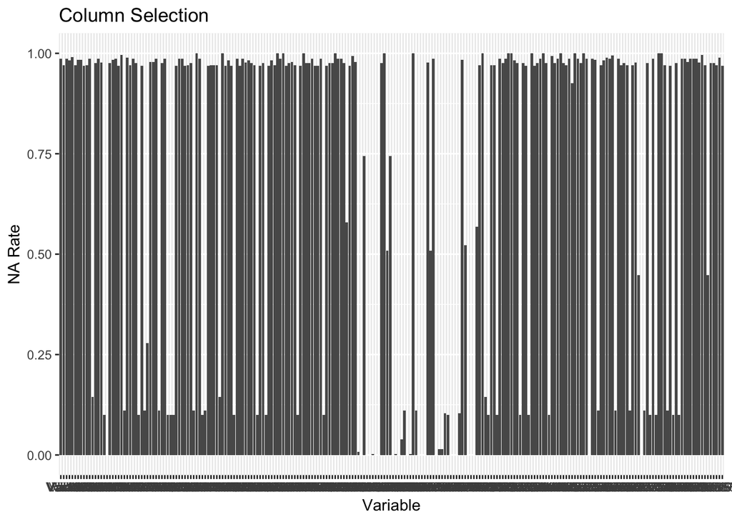

```r
n <- nrow(data_train)
na_rate <- apply(data_train, 2, function(x) {sum(is.na(x))/n})
na_rate_df <- as.data.frame(na_rate)
na_rate_df <- cbind(newColName = rownames(na_rate_df), na_rate_df)
rownames(na_rate_df) <- 1:nrow(na_rate_df)
colnames(na_rate_df) <- c("Variable", "NA_Rate")
ggplot(data = na_rate_df) +
  geom_bar(mapping = aes(x = Variable, y = NA_Rate), stat = "identity") +
  xlab("Variable") +
  ylab("NA Rate") +
  labs(title = "Column Selection")
```

Do: - Inspect response variables

```r
resp_vars <- cbind(target_churn, target_appentency, target_upselling)
resp_sum <- summary(resp_vars)
churn_mean <- mean(resp_vars$churn)
appent_mean <- mean(resp_vars$appentency)
upsell_mean <- mean(resp_vars$upselling)
classes_mean <- data.frame("Churn" = churn_mean,
                          "Appentency" = appent_mean,
                          "Upsell" = upsell_mean)

classes_plot <- classes_mean %>%
  gather('Churn', 'Appentency', 'Upsell',  key = "Name", value = "Mean")

tcs <- summary(target_churn)
tas <- summary(target_appentency)
tus <- summary(target_upselling)

cbind(tcs, tas, tus)
```

```
##      churn             appentency          upselling
##  "Min.   :-1.0000  " "Min.   :-1.0000  " "Min.   :-1.0000  "
##  "1st Qu.:-1.0000  " "1st Qu.:-1.0000  " "1st Qu.:-1.0000  "
##  "Median :-1.0000  " "Median :-1.0000  " "Median :-1.0000  "
##  "Mean   :-0.8531  " "Mean   :-0.9644  " "Mean   :-0.8527  "
##  "3rd Qu.:-1.0000  " "3rd Qu.:-1.0000  " "3rd Qu.:-1.0000  "
##  "Max.   : 1.0000  " "Max.   : 1.0000  " "Max.   : 1.0000  "
```

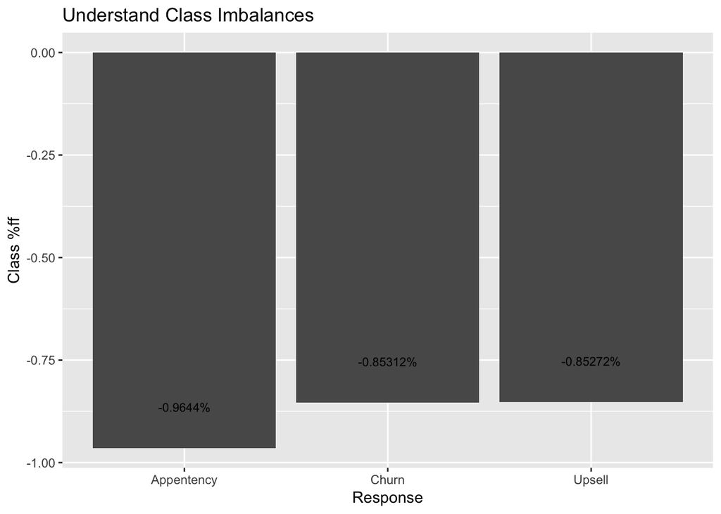

```r
ggplot(data = classes_plot) +
  geom_bar(mapping = aes(x = classes_plot$Name, y = classes_plot$Mean), stat = "identity") +
  geom_text(aes(x = Name, y = Mean + .1,    # nudge above top of bar
                  label = paste0(Mean, '%')),    # prettify
              position = position_dodge(width = .9),
              size = 3) +
  xlab("Response") +
  ylab("Class %ff") +
  labs(title = "Understand Class Imbalances")
```

Check: - Variables are no encoded for binary classification

Act: - Encode resposne variables as 0/1

Do (from above): - Encode response variables as 0/1

```r
target_churn$churn[target_churn$churn == -1] <- 0
target_appentency$appentency[target_appentency$appentency == -1] <- 0
target_upselling$upselling[target_upselling$upselling == -1] <- 0
```

Check: - Check encoding

```r
tcs1 <- summary(target_churn)
tas1 <- summary(target_appentency)
tus1 <- summary(target_upselling)

cbind(tcs1, tas1, tus1)
```

```
##      churn             appentency         upselling
##  "Min.   :0.00000  " "Min.   :0.0000  " "Min.   :0.00000  "
##  "1st Qu.:0.00000  " "1st Qu.:0.0000  " "1st Qu.:0.00000  "
##  "Median :0.00000  " "Median :0.0000  " "Median :0.00000  "
##  "Mean   :0.07344  " "Mean   :0.0178  " "Mean   :0.07364  "
##  "3rd Qu.:0.00000  " "3rd Qu.:0.0000  " "3rd Qu.:0.00000  "
##  "Max.   :1.00000  " "Max.   :1.0000  " "Max.   :1.00000  "
```

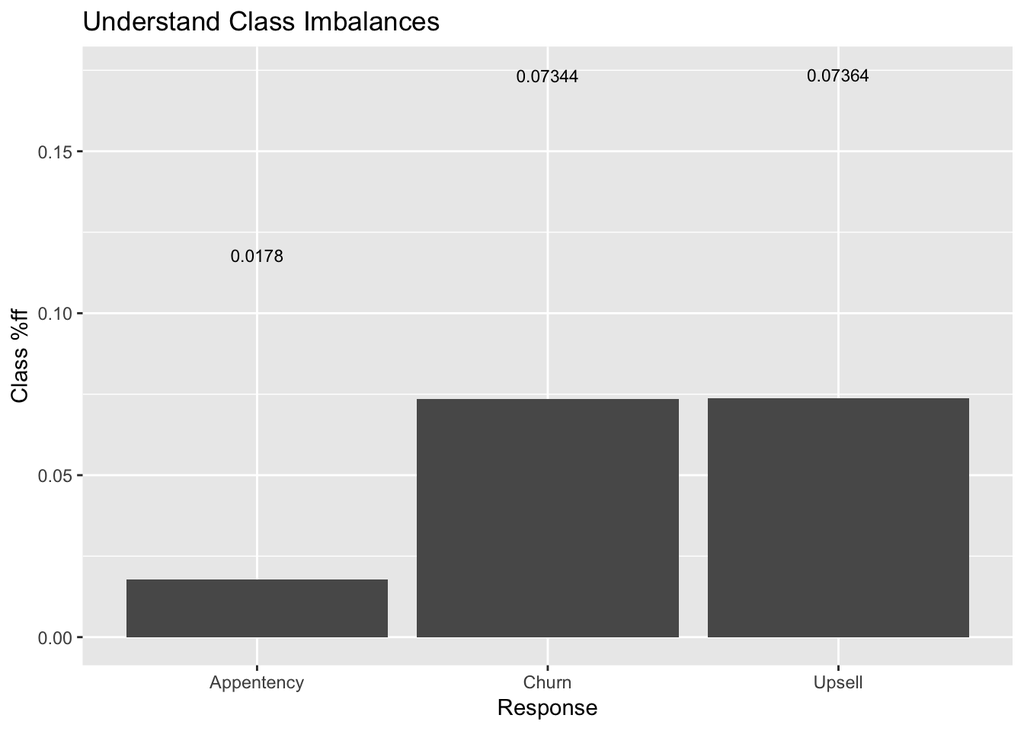

```r
resp_vars1 <- cbind(target_churn, target_appentency, target_upselling)
resp_sum1 <- summary(resp_vars1)
churn_mean1 <- mean(resp_vars1$churn)
appent_mean1 <- mean(resp_vars1$appentency)
upsell_mean1 <- mean(resp_vars1$upselling)
classes_mean1 <- data.frame("Churn" = churn_mean1,
                          "Appentency" = appent_mean1,
                          "Upsell" = upsell_mean1)

classes_plot1 <- classes_mean1 %>%
  gather('Churn', 'Appentency', 'Upsell',  key = "Name", value = "Mean")

ggplot(data = classes_plot1) +
  geom_bar(mapping = aes(x = classes_plot1$Name, y = classes_plot1$Mean), stat = "identity") +
  geom_text(aes(x = Name, y = Mean + .1,    # nudge above top of bar
                  label = paste0(Mean, '')),    # prettify
              position = position_dodge(width = .9),
              size = 3) +
  xlab("Response") +
  ylab("Class %ff") +
  labs(title = "Understand Class Imbalances")
```

Act: - NOTE: Strong class imbalance of response variables. May effect model performance given most techniques are designed to minimize error, not true positive rate. - No action required at this time

Do: - Remove variables with all or excessive NA rate

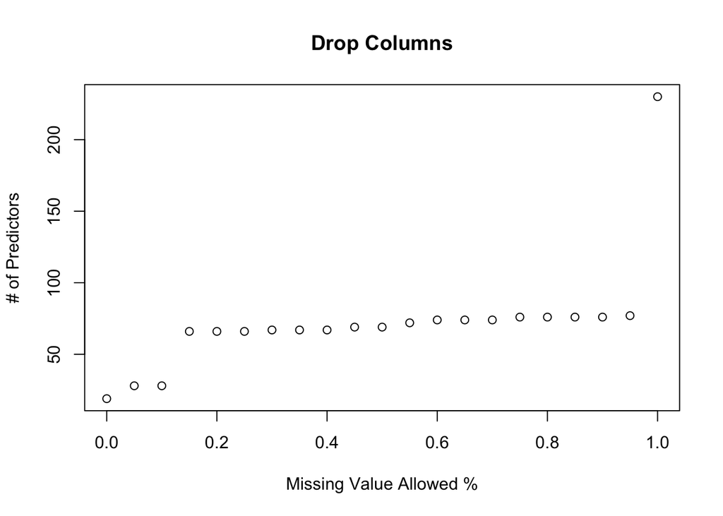

```r
ind <- seq(0, 1, 0.05)
answer <- c()

for (i in ind) {
na_flag <- ifelse(na_rate <= i, 1, 0)
col_sub <- na_flag[na_flag == 1]
col_num <- length(col_sub)
answer <- append(answer, col_num)
}

plot(ind, answer, xlab = "Missing Value Allowed %", ylab = "# of Predictors", title(main = "Drop Columns"))
```

```r
na_flag1 <- ifelse(na_rate <= .2, 1, 0)
col_sub1 <- na_flag1[na_flag == 1]
data_train <- data_train[,col_sub1 == 1]

table(sapply(data_train, class))
```

```
##
##  factor numeric
##      28      38
```

Check: - Verify columns were removed

```r
dim(data_train)
```

```
## [1] 50000    66
```

Act: - No action required at this time

Do: - Convert low-count numeric variables to factors

```r
table(sapply(data_train, class))
```

```
##
##  factor numeric
##      28      38
```

```r
data_train[sapply(data_train, function(x) {(length(unique(x)))}) <= 5] <- lapply(data_train[sapply(data_train, function(x) {length(unique(x))}) <= 5], as.factor)
```

Check: - Verify a change in column types

```r
table(sapply(data_train, class))
```

```
##
##  factor numeric
##      30      36
```

Act: - No action required

Do: - Maintain visibility of NAs for imputation and modeling by constructing dummy variable matrix for NAs

```r
df_names <- names(data_train)
n_len <- nrow(data_train)
p_len <- ncol(data_train)
dummy_df <-data.frame(matrix(NA, nrow = n_len, ncol = p_len))
colnames(dummy_df) <- df_names
colnames(dummy_df) <- paste(df_names, "_D", sep = "")


dummy_df[is.na(data_train)] <- 1
dummy_df[is.na(dummy_df)] <- 0
```

Check: - NA count in data_train and count in dummy_df are equal

```r
sum(is.na(data_train))
```

```
## [1] 207854
```

```r
sum(dummy_df == 1)
```

```
## [1] 207854
```

Act: - No action required at this time

Do: - Impute NA values for integer, numeric, and factor variables

Impute values for quantitative variables Impute for numeric

```r
for (i in names(data_train)) {
 vclass <- class(pull(data_train, i))
 if (vclass == "numeric"){
   data_train[is.na(data_train[,i]),i] <- colMeans(data_train[,i],na.rm = TRUE)
 }
}
```

Impute for integer Create a function to find the mode of integers excluding NAs

```r
Modes <- function(x) {
  ux <- unique(x)
  tab <- tabulate(match(x, ux))
  tab[is.na(ux)] <- 0
  ux[tab == max(tab)]
  }


mode_df <- sapply(data_train, Modes)
mode_df <- as.data.frame(mode_df)
mode_df <- cbind(newColName = rownames(mode_df), mode_df)
rownames(mode_df) <- 1:nrow(mode_df)
colnames(mode_df) <- c("Variable", "Mode")

n <- mode_df$Variable
mode_df <- as.data.frame(t(mode_df[,-1]))
colnames(mode_df) <- n

mode_df_fun <- function (x) {
  col_name <- names(x)
  value <- mode_df[1,col_name]
  return(value)
}
```

Impute integer NAs

```r
for (i in names(data_train)) {
 vclass <- class(pull(data_train, i))
 if (vclass == "integer") {
   data_train[is.na(data_train[,i]),i] <- mode_df[,i]
 }
}
```

Replace NAs with “missing” level

```r
data_train <- as.data.frame(data_train)
for (i in names(data_train)) {
  vclass <- class(data_train[,i])
  if (vclass == 'factor') {
    levels(data_train[,i]) <- c(levels(data_train[,i]), 'missing')
    data_train[is.na(data_train[,i]), i] <- 'missing'
  }
}
```

Check: - Veryify all NAs have been replaced

```r
sum(is.na(data_train))
```

```
## [1] 0
```

Act: - No action required at this time

Do: - Encode variable encoding and type to fit modeling technqiues

```r
for (i in names(data_train)) {
  vclass <- class(data_train[,i])
  if (vclass == "factor") {
    level_n <- length(levels(data_train[,i]))
    levels(data_train[,i]) <- 0:(level_n-1)
  }
}
```

Check: - Verify by inspection all levels are numeric

```r
levels_def <- c()
for (i in names(data_train)) {
  vclass <- class(pull(data_train, i))
  if (vclass == "factor") {
  level_ <- levels(pull(data_train, i))
  levels_def <- append(levels_def, level_)
  }
}
levels_def <- as.numeric(levels_def)
levels_def
```

[output not shown]

[output cut: 3685 more lines]

Act: - No action required at this time - NOTE: Excessive factor levels may require new encoding - find count of number of columns with a given factor count

```r
levels_all <- c()
for (i in names(data_train)) {
  vclass <- class(pull(data_train, i))
  if (vclass == "factor") {
  level_list <- length(levels(pull(data_train, i)))
  levels_all <- append(levels_all, level_list)
  }
}
levels_all <- as.data.frame(levels_all)
max(levels_all$levels_all)
```

```
## [1] 13991
```

```r
table(levels_all)
```

```
## levels_all
##     3     4     5     6     7     8    15    22    23    24    31    52
##     3     1     4     1     1     2     1     1     1     2     1     1
##    82   101   226   362  2017  4292  5074  5714 13991
##     1     1     1     1     1     3     1     1     1
```

Do: - Create two data sets; one that preserves factors and one that converts factor columns to numeric for modeling techniques

```r
fac_data_train <- data_train
indx <- sapply(data_train, is.factor)
data_train[,indx] <- lapply(data_train[,indx], function(x) as.numeric(as.character(x)))
```

Check: - Inspect column types for factor/numeric and numeric respectively.

```r
sapply(fac_data_train, class)
```

```
##      Var6      Var7     Var13     Var21     Var22     Var24     Var25
## "numeric" "numeric" "numeric" "numeric" "numeric" "numeric" "numeric"
##     Var28     Var35     Var38     Var44     Var57     Var65     Var73
## "numeric" "numeric" "numeric" "numeric" "numeric" "numeric" "numeric"
##     Var74     Var76     Var78     Var81     Var83     Var85    Var109
## "numeric" "numeric" "numeric" "numeric" "numeric" "numeric" "numeric"
##    Var112    Var113    Var119    Var123    Var125    Var132    Var133
## "numeric" "numeric" "numeric" "numeric" "numeric" "numeric" "numeric"
##    Var134    Var140    Var143    Var144    Var149    Var153    Var160
## "numeric" "numeric"  "factor" "numeric" "numeric" "numeric" "numeric"
##    Var163    Var173    Var181    Var192    Var193    Var195    Var196
## "numeric"  "factor" "numeric"  "factor"  "factor"  "factor"  "factor"
##    Var197    Var198    Var199    Var202    Var203    Var204    Var205
##  "factor"  "factor"  "factor"  "factor"  "factor"  "factor"  "factor"
##    Var206    Var207    Var208    Var210    Var211    Var212    Var216
##  "factor"  "factor"  "factor"  "factor"  "factor"  "factor"  "factor"
##    Var217    Var218    Var219    Var220    Var221    Var222    Var223
##  "factor"  "factor"  "factor"  "factor"  "factor"  "factor"  "factor"
##    Var226    Var227    Var228
##  "factor"  "factor"  "factor"
```

```r
sapply(data_train, class)
```

```
##      Var6      Var7     Var13     Var21     Var22     Var24     Var25
## "numeric" "numeric" "numeric" "numeric" "numeric" "numeric" "numeric"
##     Var28     Var35     Var38     Var44     Var57     Var65     Var73
## "numeric" "numeric" "numeric" "numeric" "numeric" "numeric" "numeric"
##     Var74     Var76     Var78     Var81     Var83     Var85    Var109
## "numeric" "numeric" "numeric" "numeric" "numeric" "numeric" "numeric"
##    Var112    Var113    Var119    Var123    Var125    Var132    Var133
## "numeric" "numeric" "numeric" "numeric" "numeric" "numeric" "numeric"
##    Var134    Var140    Var143    Var144    Var149    Var153    Var160
## "numeric" "numeric" "numeric" "numeric" "numeric" "numeric" "numeric"
##    Var163    Var173    Var181    Var192    Var193    Var195    Var196
## "numeric" "numeric" "numeric" "numeric" "numeric" "numeric" "numeric"
##    Var197    Var198    Var199    Var202    Var203    Var204    Var205
## "numeric" "numeric" "numeric" "numeric" "numeric" "numeric" "numeric"
##    Var206    Var207    Var208    Var210    Var211    Var212    Var216
## "numeric" "numeric" "numeric" "numeric" "numeric" "numeric" "numeric"
##    Var217    Var218    Var219    Var220    Var221    Var222    Var223
## "numeric" "numeric" "numeric" "numeric" "numeric" "numeric" "numeric"
##    Var226    Var227    Var228
## "numeric" "numeric" "numeric"
```

Act: - No action required at this time

REFLECTIONS

Reflections on Data Cleaning - following up on notes in actions sections above.

Factor Variables: Factor variable will be a significant role in model building and testing. There are common challenges to working with factor variables: - Too many levels - Inbalance in occurance of levels (relative occurance is inbalanced) - Masked levels - Encoding constraints based on modeling technique/tools used It may become apparent based on model performance that some or all of the issues above will need to be addressed.

- NOTE: Strong class inbalance of response variables. May effect model performance given most techniques are designed to minimize error rate and not true positive rate or AUC

DATA MODELING AND ANALYSIS

Plan: - Split training and test sets from data_train for model building and validation - Build and test KNN model - Build and test decision tree model - Build and test logistic regression model - Compute AUC

Do: - Create training and test sets from data_train to support only numeric variables for KNN

```r
set.seed(2018)
n_row <- nrow(data_train)
data_train <- cbind(target_churn, data_train)
rows <- sample(n_row, n_row*.7)
train_set <- data_train[rows, ]
test_set <- data_train[-rows, ]
```

```r
knnpred <- knn(train_set,test_set,train_set$churn, k = 1)
A = table(knnpred,test_set$churn)
A
```

```
##
## knnpred     0     1
##       0 12957  1001
##       1   955    87
```

```r
TestErrorKNN1 = (A[1,2]+A[2,1])/sum(A)
TestErrorKNN1
```

```
## [1] 0.1304
```

```r
library(pROC)
```

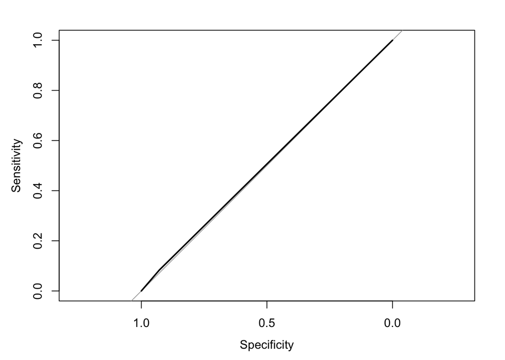

```
## Area under the curve: 0.5059
```

```r
plot.roc(knnpred,test_set$churn)$auc
```

For K = 5

```r
# For K = 5
knnpred <- knn(train_set,test_set,train_set$churn, k = 5)
B = table(knnpred,test_set$churn)
B
```

```
##
## knnpred     0     1
##       0 13861  1079
##       1    51     9
```

```r
TestErrorKNN5 = (B[1,2]+B[2,1])/sum(B)
TestErrorKNN5
```

```
## [1] 0.07533333
```

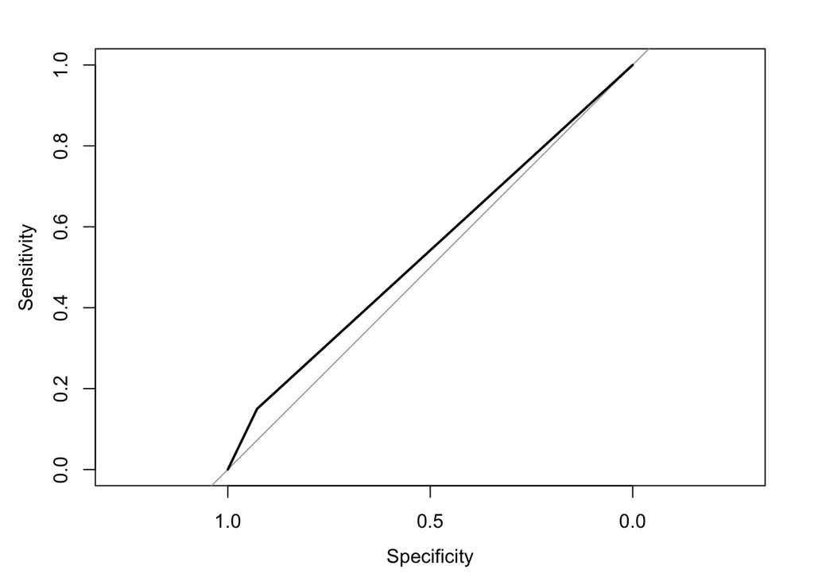

```
## Area under the curve: 0.5389
```

```r
plot.roc(knnpred, test_set$churn)$auc
```

For K = 10

```r
# For K = 10
knnpred <- knn(train_set,test_set,train_set$churn, k = 10)
C = table(knnpred,test_set$churn)
C
```

```
##
## knnpred     0     1
##       0 13909  1087
##       1     3     1
```

```r
TestErrorKNN10 = (C[1,2]+C[2,1])/sum(C)
TestErrorKNN10
```

```
## [1] 0.07266667
```

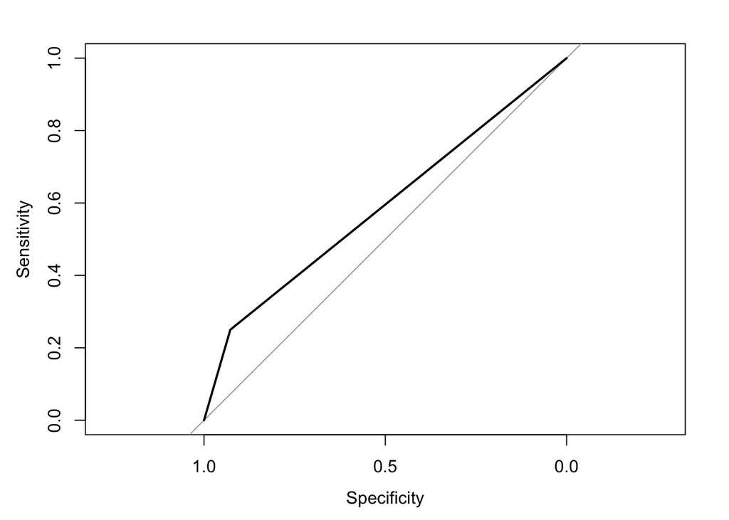

```
## Area under the curve: 0.5888
```

```r
plot.roc(knnpred,test_set$churn)$auc
```

For K = 15

```r
# For K = 15
knnpred <- knn(train_set,test_set,train_set$churn, k = 15)
D = table(knnpred,test_set$churn)
D
```

```
##
## knnpred     0     1
##       0 13912  1087
##       1     0     1
```

```r
TestErrorKNN15 = (D[1,2]+D[2,1])/sum(D)
TestErrorKNN15
```

```
## [1] 0.07246667
```

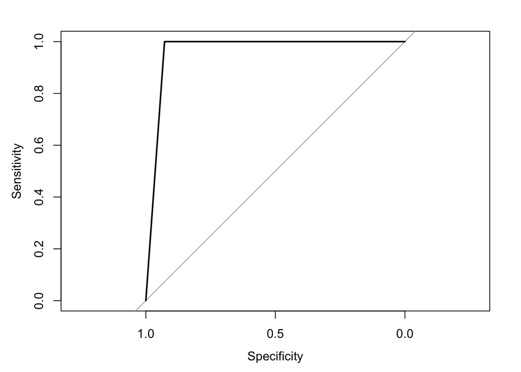

```
## Area under the curve: 0.9638
```

```r
plot.roc(knnpred,test_set$churn)$auc
```

For K = 18

Check: - ROC ws computed for all but K = 18.

Act: - No action required at this time. - K = 18 failed to compute becasue the model failed to predict an positive observations

Do: - Build a decision tree model

```r
tree_model <- tree(as.factor(churn) ~ ., train_set)
tree_model
```

```
## node), split, n, deviance, yval, (yprob)
##       * denotes terminal node
##
## 1) root 35000 18440 0 ( 0.92617 0.07383 )
##   2) Var74 < 3.5 14278  9337 0 ( 0.89915 0.10085 ) *
##   3) Var74 > 3.5 20722  8851 0 ( 0.94479 0.05521 ) *
```

Check: - Results indicate the data does not have enough variation for the decision tree to train on

Act: - Use a more robust variant of decision trees; random forests.

Do: - Build a random forest model (from above)

```r
forest_model <- randomForest(as.factor(churn) ~ .,
                   ntree = 100,
                   data = train_set)

tree_pred <- predict(forest_model, test_set, type = "class")
mean(tree_pred != test_set$churn)
```

```
## [1] 0.07266667
```

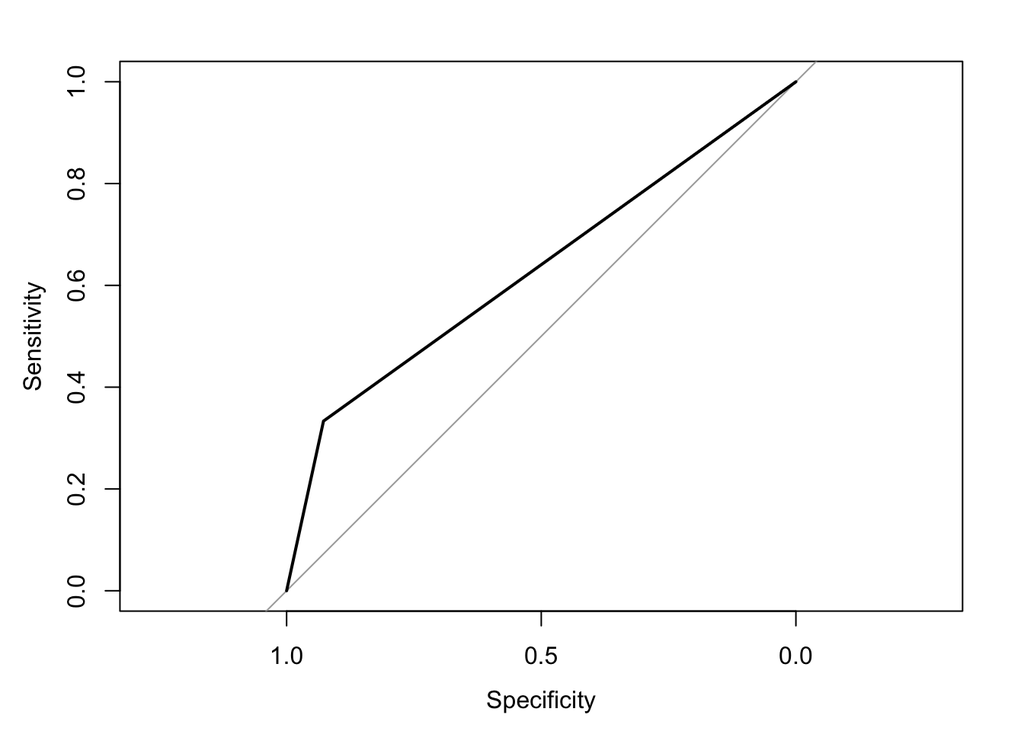

```
## Area under the curve: 0.6305
```

```r
plot.roc(tree_pred,test_set$churn)$auc
```

Check: - AUC was computed

Act: - No action required at this time - NOTE: Next step is to vary forest parameters and prune with cross validation

```r
set.seed(2018)
n_row <- nrow(fac_data_train)
fac_data_train <- cbind(target_churn, fac_data_train)
rows <- sample(n_row, n_row*.7)
fac_train_set <- fac_data_train[rows, ]
fac_test_set <- fac_data_train[-rows, ]
```

Do: - Build logistic regressoin model

```r
log_fit <- glm(churn ~ ., data = train_set, family = binomial)
summary(log_fit)
```

```
##
## Call:
## glm(formula = churn ~ ., family = binomial, data = train_set)
##
## Deviance Residuals:
##     Min       1Q   Median       3Q      Max
## -1.6039  -0.4339  -0.3543  -0.2772   3.4911
##
## Coefficients: (1 not defined because of singularities)
##               Estimate Std. Error z value Pr(>|z|)
## (Intercept) -1.654e+00  4.564e-01  -3.625 0.000289 ***
## Var6        -2.247e-07  1.400e-05  -0.016 0.987201
## Var7        -2.337e-02  5.616e-03  -4.161 3.17e-05 ***
## Var13        6.851e-06  8.943e-06   0.766 0.443618
## Var21       -3.839e-04  4.177e-04  -0.919 0.358111
## Var22       -1.888e-04  3.736e-04  -0.505 0.613286
## Var24       -7.103e-03  4.674e-03  -1.520 0.128583
## Var25        3.930e-04  2.886e-04   1.362 0.173344
## Var28        2.246e-04  2.196e-04   1.023 0.306538
## Var35       -6.267e-02  3.027e-02  -2.071 0.038373 *
## Var38       -8.842e-09  2.546e-08  -0.347 0.728402
## Var44       -5.223e-02  2.296e-02  -2.275 0.022888 *
## Var57       -1.333e-02  1.020e-02  -1.306 0.191493
## Var65        2.624e-03  3.005e-03   0.873 0.382497
## Var73       -6.147e-03  9.182e-04  -6.694 2.17e-11 ***
## Var74       -6.343e-04  1.630e-04  -3.892 9.95e-05 ***
## Var76        2.508e-08  1.894e-08   1.325 0.185316
## Var78       -1.145e-01  5.122e-02  -2.236 0.025341 *
## Var81        3.448e-07  2.231e-07   1.546 0.122165
## Var83        1.486e-04  6.411e-04   0.232 0.816720
## Var85        2.147e-04  2.100e-03   0.102 0.918592
## Var109      -3.070e-05  3.460e-04  -0.089 0.929284
## Var112       8.566e-04  3.219e-04   2.661 0.007791 **
## Var113       2.500e-07  3.337e-08   7.491 6.83e-14 ***
## Var119       3.451e-06  2.167e-05   0.159 0.873472
## Var123       9.533e-04  3.415e-04   2.792 0.005245 **
## Var125       1.831e-08  2.450e-07   0.075 0.940428
## Var132       4.691e-02  1.821e-02   2.576 0.009986 **
## Var133      -1.840e-08  2.532e-08  -0.727 0.467452
## Var134       3.975e-08  6.956e-08   0.571 0.567697
```

[output cut: 32 more lines]

```
## Var222      -2.159e-05  1.703e-05  -1.267 0.205024
## Var223       3.333e-02  4.339e-02   0.768 0.442460
## Var226      -2.637e-03  3.457e-03  -0.763 0.445482
## Var227       1.531e-02  2.155e-02   0.710 0.477414
## Var228       7.942e-03  5.369e-03   1.479 0.139072
## ---
## Signif. codes:  0 '***' 0.001 '**' 0.01 '*' 0.05 '.' 0.1 ' ' 1
##
## (Dispersion parameter for binomial family taken to be 1)
##
##     Null deviance: 18440  on 34999  degrees of freedom
## Residual deviance: 17622  on 34934  degrees of freedom
## AIC: 17754
##
## Number of Fisher Scoring iterations: 7
```

```r
log_fit_prob <- predict(log_fit, type = "response")
head(log_fit_prob)
```

```
##      16808      23186       3030       9872      23714      15051
## 0.12064432 0.10402012 0.07732743 0.04410016 0.10241504 0.10977942
```

```r
log_fit_prob <- as.data.frame(log_fit_prob)
log_fit_prob$resp <- 0
log_fit_prob$resp[log_fit_prob$log_fit_prob > .5] <- 1
log_fit_pred <- cbind(train_set$churn, log_fit_prob)
table(log_fit_pred$resp, log_fit_pred$`train_set$churn`)
```

```
##
##         0     1
##   0 32411  2583
##   1     5     1
```

```r
log_acc <- mean(log_fit_pred$resp == log_fit_pred$`train_set$churn`)
log_acc
```

```
## [1] 0.9260571
```

```r
1 - mean(log_acc)
```

```
## [1] 0.07394286
```

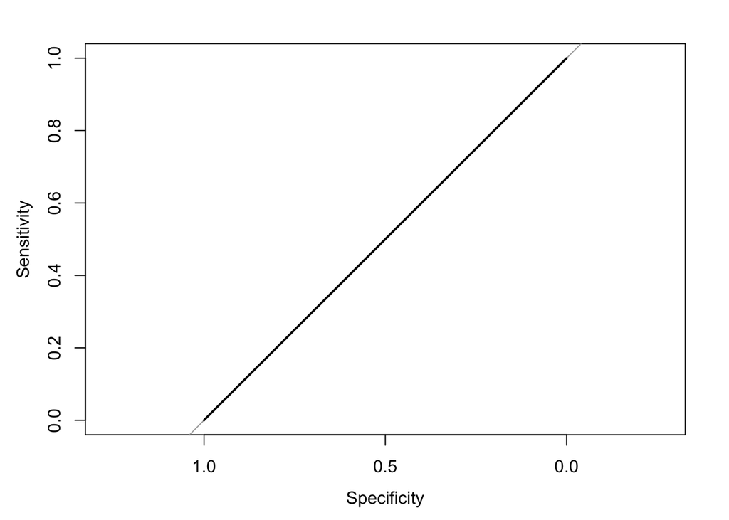

```
## Area under the curve: 0.5001
```

```r
plot.roc(log_fit_pred$`train_set$churn`,log_fit_pred$resp)$auc
```

Check: - The logistic regression model containing all predictors is no better than the null model

Act: - This deficiancy might be attributable insignificant predictors in the model or class imbalances in the training data. - Use Lasso and ridge regularization methods for variable selection - Use resampling methods to address class imbalances

Do: - Ridge for Logistic Regression Variable Selection

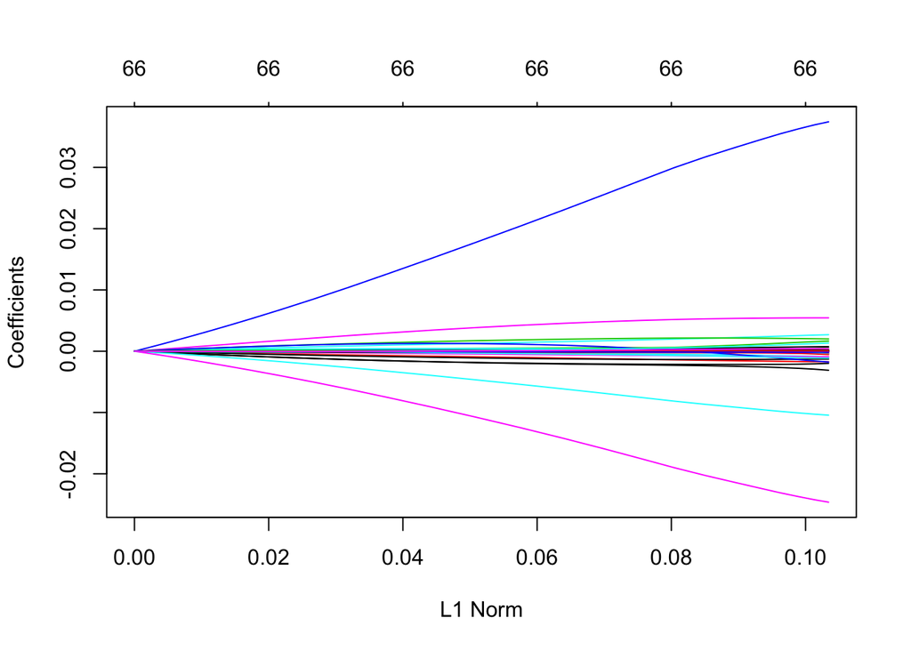

```r
x <- model.matrix(churn ~., train_set)
y <- train_set$churn
grid <- 10^seq(10,-2,length=100)
rig_log_fit <- glmnet(x, y, alpha = 0, lambda = grid)
plot(rig_log_fit)
```

Tune Lambda Parameter with Cross Validation

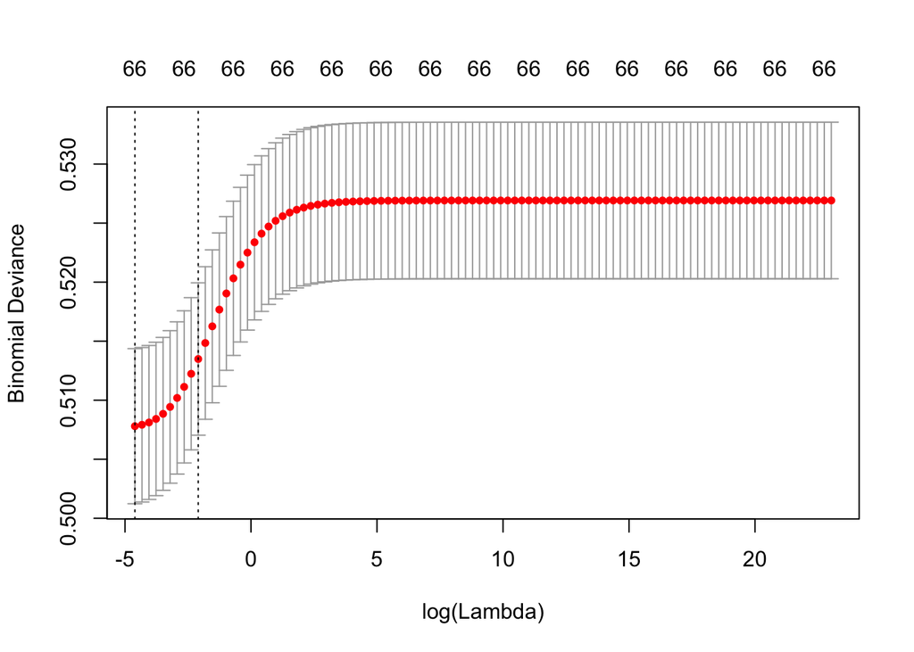

```r
rig_cv <- cv.glmnet(x, y, alpha = 0, family = "binomial", lambda = grid)
plot(rig_cv)
```

```r
lambda_opt_rig <- rig_cv$lambda.min
lambda_opt_rig
```

```
## [1] 0.01
```

```r
x_test <- model.matrix(churn ~., test_set)
rig_prob <- predict(rig_cv, s = lambda_opt_rig, newx = x_test, type = "response")
rig_prob <- as.data.frame(rig_prob)
rig_prob$resp <- 0
rig_prob$resp[rig_prob$`1` > .5] <- 1
rig_pred <- cbind(test_set$churn, rig_prob)
table(rig_pred$resp, rig_pred$`test_set$churn`)
```

```
##
##         0     1
##   0 13912  1088
```

```r
rig_acc <- mean(rig_pred$resp == rig_pred$`test_set$churn`)
rig_acc
```

```
## [1] 0.9274667
```

```r
1 - mean(rig_acc)
```

```
## [1] 0.07253333
```

```r
# install.packages("flare")
library(flare)
```

```r
# plot.roc(rig_prob$resp,test_set$churn)$auc
```

Check: - Unable to compute AUC becuase no positive predicted response classes

Act: - Further data cleaning is necessary

Lasso for Logistic Regression Variable Selection

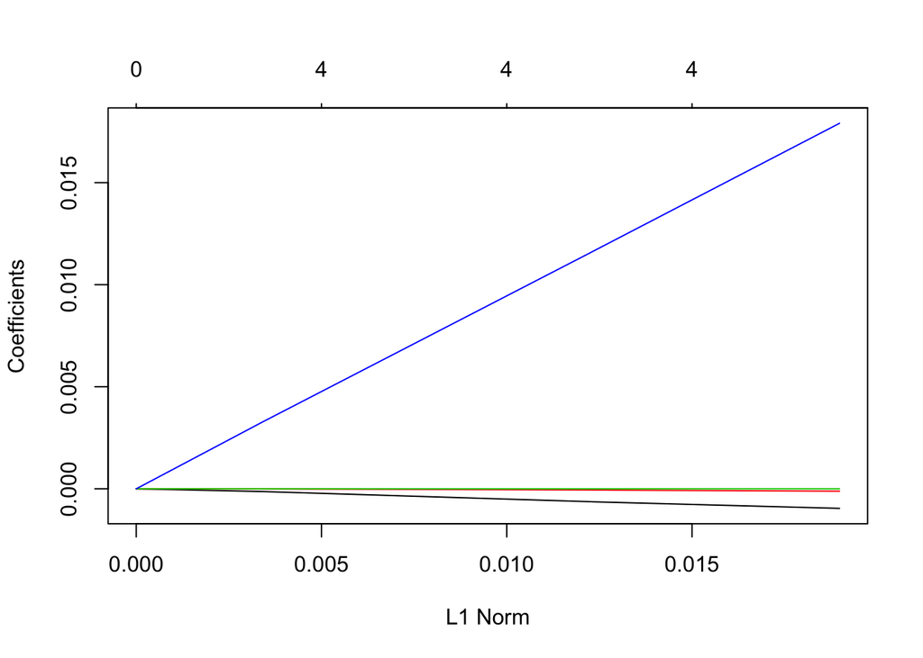

```r
x <- model.matrix(churn ~., train_set)
y <- train_set$churn
grid <- 10^seq(10,-2,length=100)
lasso_log_fit <- glmnet(x, y, alpha = 1, lambda = grid)
plot(lasso_log_fit)
```

Tune Lambda Parameter with Cross Validation

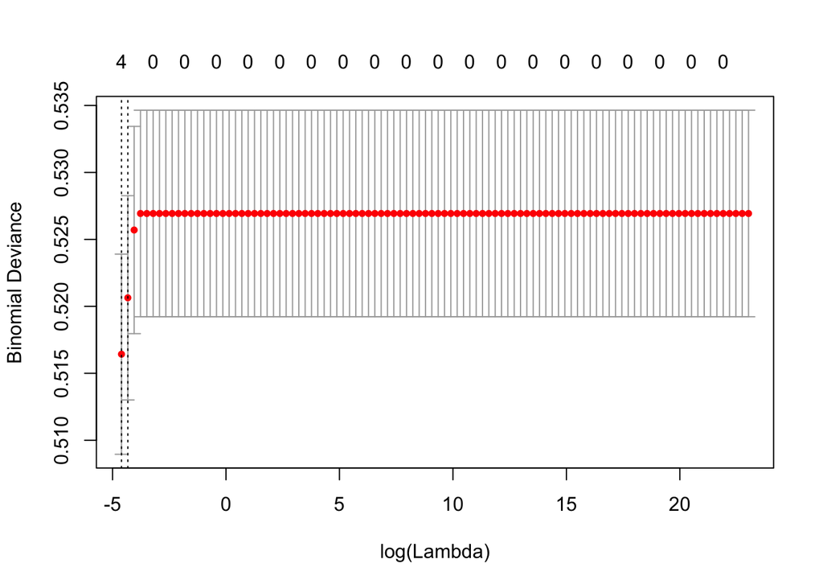

```r
lasso_cv <- cv.glmnet(x, y, alpha = 1, family = "binomial", lambda = grid)
plot(lasso_cv)
```

```r
lambda_opt <- lasso_cv$lambda.min
lambda_opt
```

```
## [1] 0.01
```

```r
x_test <- model.matrix(churn ~., test_set)
lasso_prob <- predict(lasso_cv, s = lambda_opt, newx = x_test, type = 'response')
lasso_prob <- as.data.frame(lasso_prob)
lasso_prob$resp <- 0
lasso_prob$resp[lasso_prob$`1` > .5] <- 1
lasso_pred <- cbind(test_set$churn, lasso_prob)
table(lasso_pred$resp, lasso_pred$`test_set$churn`)
```

```
##
##         0     1
##   0 13912  1088
```

```r
lasso_acc <- mean(lasso_pred$resp == lasso_pred$`test_set$churn`)
lasso_acc
```

```
## [1] 0.9274667
```

```r
1 - mean(lasso_acc)
```

```
## [1] 0.07253333
```

```r
# plot.roc(lasso_prob$resp,test_set$churn)$auc
```

Check: - Unable to compute AUC becuase no positive predicted response classes

Act: - Further data cleaning is necessary

MODEL ANALYSIS Plan: - Evaluatee initial model performance based on AUC - Iterate on model building and testing based on results